# Uvod u vizualizaciju podataka u R-u

Milutin Pejović

02 December 2020

# Vizualizacija podataka u R-u

Vizualizacija podataka podrazumeva kreiranje različitih vrsta grafika i odnosno prikaza podataka u cilju otkrivanja informacija koje na prvi pogled nisu tako uočljive. `R` ima tri odvojena okruženja za kreiranje grafika, `base`, `Lattice` i `ggplot`. U poslednje vreme `ggplot` je daleko najpopularniji paket i upravo on doprinosi velikoj popularizaciji R-a. Sa druge strane `base` plot nikada neće izaći iz upotrebe medju R korisnicima. Njega odlikuje jednostavnost poziva funkcija.

## `base` plot

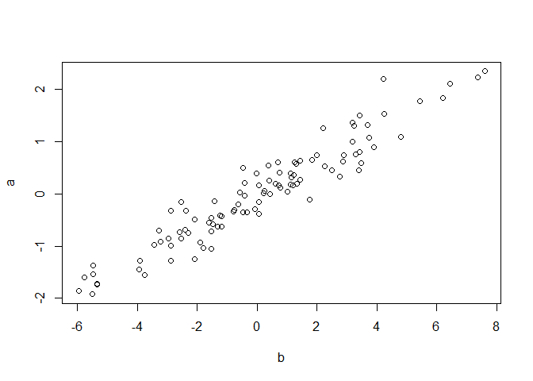

```r
a <- rnorm(100)
b <- 3*a + rnorm(100)
ab <- data.frame(a, b)

plot(a ~ b, data = ab)
```

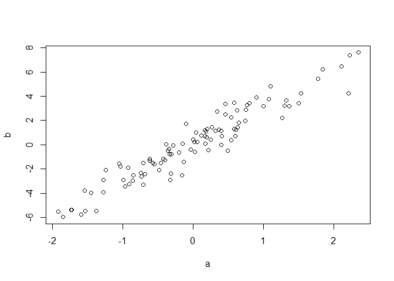

```r
plot(a, b)
```

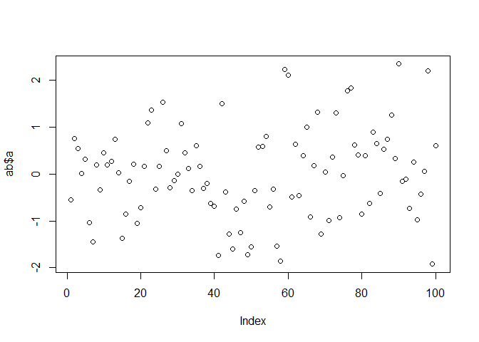

```r
plot(ab$a)
```

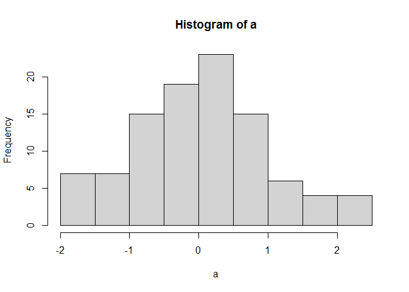

```r
hist(a)
```

Glavni parametri fukcije plot su:

`+`type` what type of plot should be drawn. Possible types are

- “p” for points,
- “l” for lines,
- “b” for both,
- “c” for the lines part alone of “b”,
- “o” for both ‘overplotted’,
- “h” for ‘histogram’ like (or ‘high-density’) vertical lines,
- “s” for stair steps,
- “S” for other steps, see ‘Details’ below,
- “n” for no plotting.
- `main` Naslov grafika
- `sub` Pod-naslov grafika
- `xlab` Naziv x-ose
- `ylab` Naziv y-ose
- `asp` odnos x-y osa

Koristei komandu `par` mogu se definisati dodatni parametri izgleda grafika.

- `pch`: simbol tačke (otvoreni krug je po default-u)
- `lty`: simbol linije
- `lwd`: debljina linije
- `col`: boja, (moguće je definisati rednim brojem, nazivom ili kodom).
- `las`: orijentacija naziva osa
- `bg`: boja pozadine
- `mar`: margine
- `oma`: spoljne margine
- `mfrow`: broj grafika po redu
- `mfcol`: broj grafika po koloni

Postoje i dodatne funkcije koje proširuju mogućnosti `base` plot okruženja.

- `plot`: kreira plot u zavisnosti od klase podataka
- `lines`: dodaje linije na već postojeći plot na osnovu matrice koordinata
- `points`: dodaje tačke na već postojeći plot
- `text`: dodaje tekst (label) na već postojeći plot na osnovu koordinata koje definišu poziciju teksta
- `mtext`: dodaje proizvoljan tekst na marginama plota
- `axis`: dodaje nazive osa

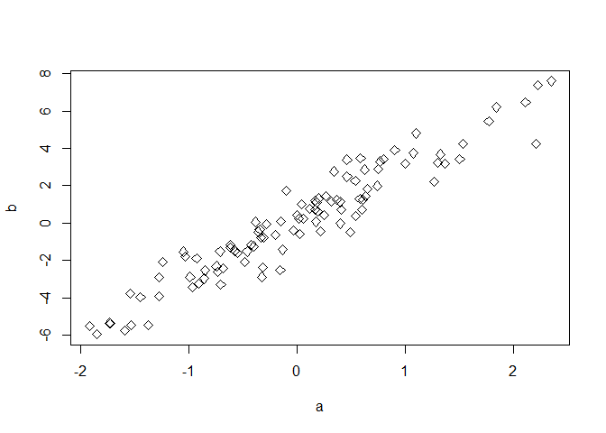

```r
plot(a, b, pch = 5)
```

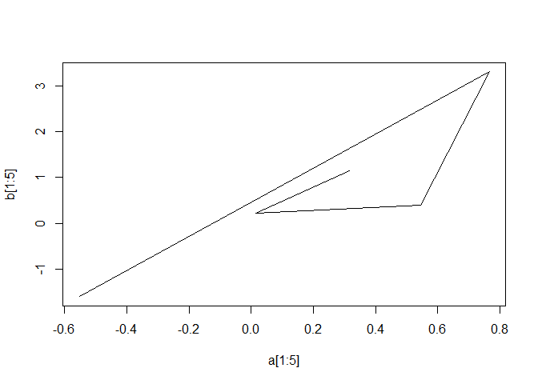

```r
plot(a[1:5], b[1:5], type = "l")
```

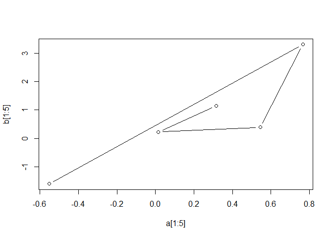

```r
plot(a[1:5], b[1:5], type = "b")
```

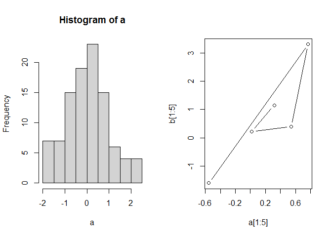

```r
# korišćenje komande `par`
par(mfrow = c(1, 2))
hist(a)
plot(a[1:5], b[1:5], type = "b")
```

## `Lattice`

`Lattice` paket je napisan da unapredi mogućnosti `base` plot okruženja. Napisan je tako da podržava kreiranje tzv. uslovnih ili `trellis` grafika - grafika koji prikazuju je jednu ili odnos više promenljivih u odnosu na druge promenljive.

Tipičan poziv Lattice plot funkcije izgleda ovako:

```javascript
graph_type(formula, data=)
```

gde je`graph_type` tip grafika (iz tabele dole). `formula` definiše promenljive koje se prikazuju kao i druge (uslovne) promenljive. Na primer, ~x prikazuje samo promenljivu `x`; ~x|A prikazuje distribuciju promenljive `x` za svaki nivo faktorske promenljive `A`. `y~x | A*B` znači prikazati odnos `x`-a i `y`-a odvojeno za svaku kombinaciju novoa faktorskih promenljivih `A` i `B`.

| tip grafika | Opis | Primer formule |
| --- | --- | --- |
| barchart | bar chart | x~A or A~x |
| bwplot | boxplot | x~A or A~x |
| cloud | 3D scatterplot | z~x*y/A |
| contourplot | 3D contour plot | z~x*y |
| densityplot | kernal density plot | ~x/A*B |
| dotplot | dotplot | ~x/A |
| histogram | histogram | ~x |
| levelplot | 3D level plot | z~y*x |
| parallel | parallel plot | data frame |
| splom | scatterplot matrix | data frame |
| stripplot | strip plots | A~x or x~A |
| xyplot | scatterplot | y~x*/A |
| wireframe | 3D wireframe graph | z~y*x |

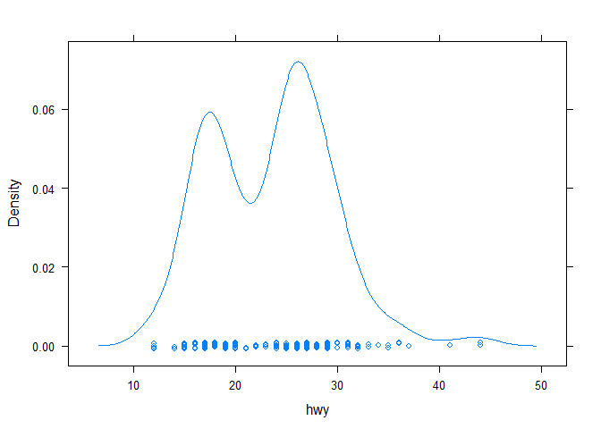

```r
library(lattice)

mpg$cyl <- factor(mpg$cyl)

densityplot(~hwy, data=mpg)
```

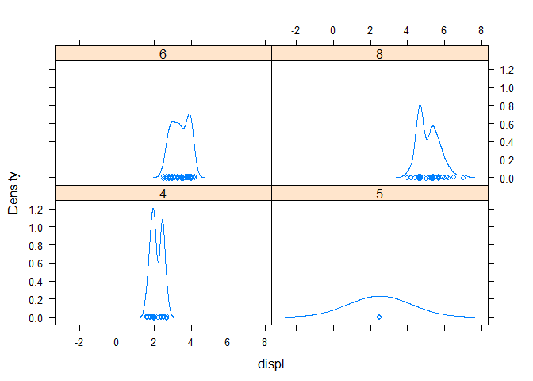

```r
densityplot(~displ|cyl, data=mpg)
```

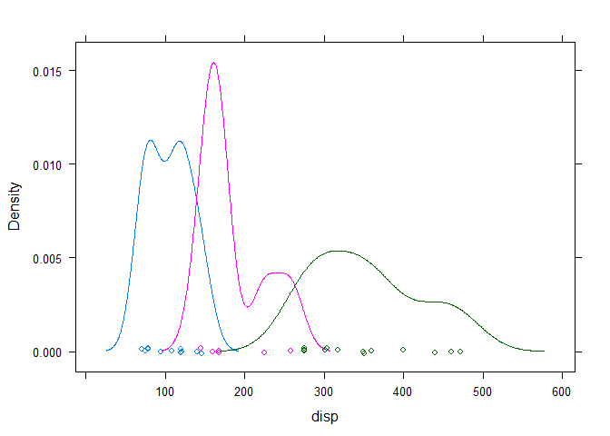

```r
densityplot(~disp, groups=cyl, data=mtcars)
```